# Algorithmic tesselation with geogrid: London testcase

For this we’ll be using the [Geogrid package](https://github.com/jbaileyh/geogrid) to turn geospatial polygons like states, counties or local authorities into regular hexagonal grids. An excellent resource for Tesselation can be foound [here](http://blog.apps.npr.org/2015/05/11/hex-tile-maps.html)

# What is a tile grid map?

his version, the map areas are reduced to a uniform size and shape (typically a square) and the tiles are arranged to roughly approximate their real-world geographic locations. It’s still a cartogram of sorts, but where the area sizing is based on the shared value of one “map unit.” Tile grid maps avoid the visual imbalances inherent to traditional choropleths, while keeping the map a quick read by forgoing the complexity of cartograms with map areas sized by a variable data point.

File grid maps are a great option for mapped state data where population figures are not part of the story we’re trying to tell with the map.

# Getting started with tile grids

```r
library(here)
library(tidyverse)
```

```r
library(ggplot2)
library(viridis)
library(gridExtra)
library(geogrid)
```

Checking London’s local authorities

```r
input_file <- system.file("extdata", "london_LA.json", package = "geogrid")
original_shapes <- read_polygons(input_file)
```

# Plotting raw data (not using grid)

For reference, lets see how London’s local authorities are actually bounded in real space. The polygon colours are given as a function of their area (yellow larger areas)

```r
raw <- read_polygons(input_file)
```

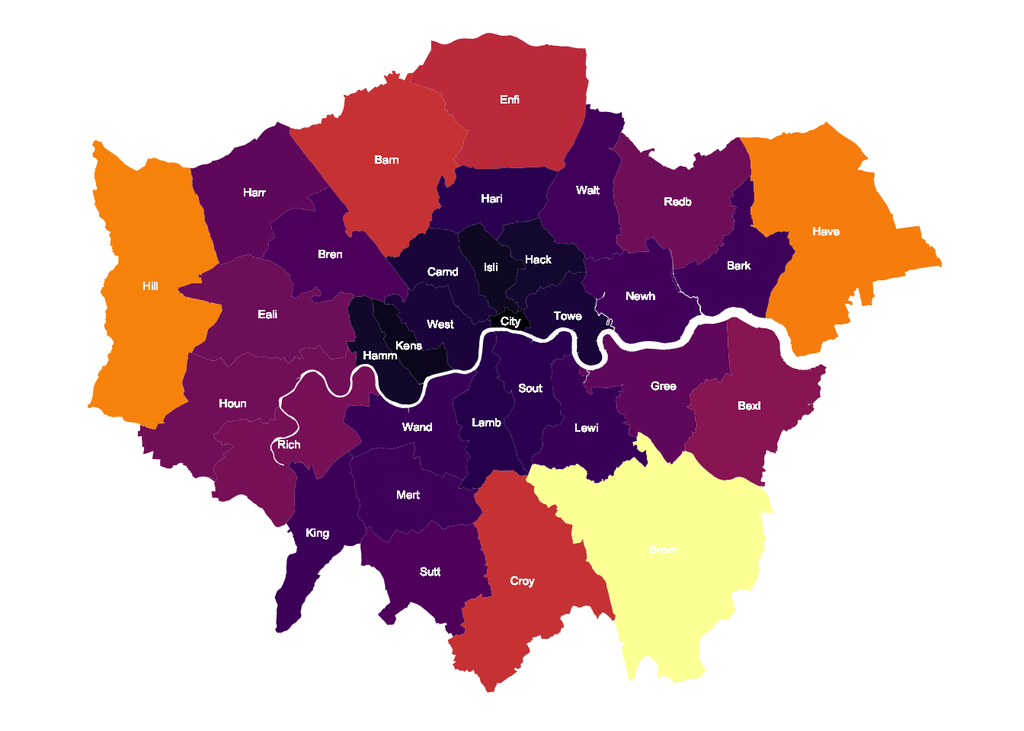

```r
raw@data$xcentroid <- sp::coordinates(raw)[,1]
raw@data$ycentroid <- sp::coordinates(raw)[,2]

clean <- function(shape) {
  shape@data$id = rownames(shape@data)
  shape.points = fortify(shape, region="id")
  shape.df = merge(shape.points, shape@data, by="id")
}

result_df_raw <- clean(raw)
rawplot <- ggplot(result_df_raw) +
  geom_polygon(aes(x = long, y = lat, fill = HECTARES, group = group)) +
  geom_text(aes(xcentroid, ycentroid, label = substr(NAME, 1, 4)), size = 2,color = "white") +
  coord_equal() +
  scale_fill_viridis(option = 'inferno') +
  guides(fill = FALSE) +
  theme_void()

rawplot
```

# Tesselate the map - Generate grids using `seed` The calculate_grid function takes in a SpatialPolygonsDataframe, a learning rate (suggestion = 0.03 to begin), a grid type hexagonal or regular and a seed value. Let’s have a look at some hexagonal grid options for the London local authorities:

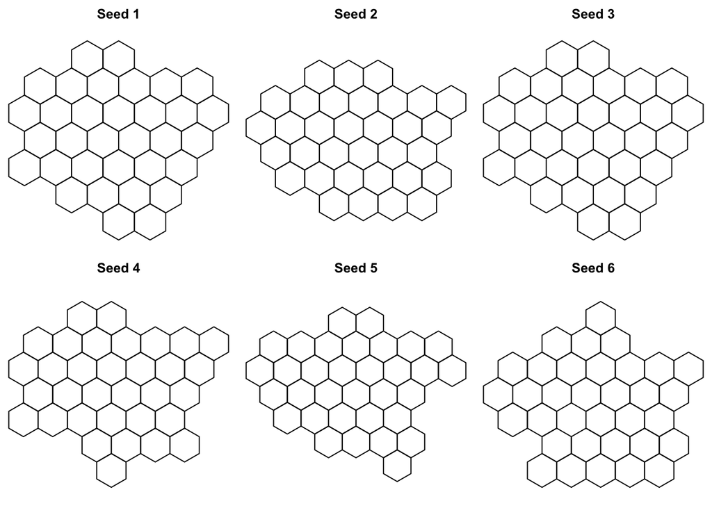

```r
par(mfrow = c(2, 3), mar = c(0, 0, 2, 0))
for (i in 1:6) {
  new_cells <- calculate_grid(shape = original_shapes, grid_type = "hexagonal", seed = i)
  plot(new_cells, main = paste("Seed", i, sep = " "))
}
```

choosing the seed = 3

```r
new_cells_hex <- calculate_grid(shape = original_shapes, grid_type = "hexagonal", seed = 3)
resulthex <- assign_polygons(original_shapes, new_cells_hex)
```

Now we can transfer this to the London area

```r
result_df_hex <- clean(resulthex)
```

Generating the hexagolad grid plot

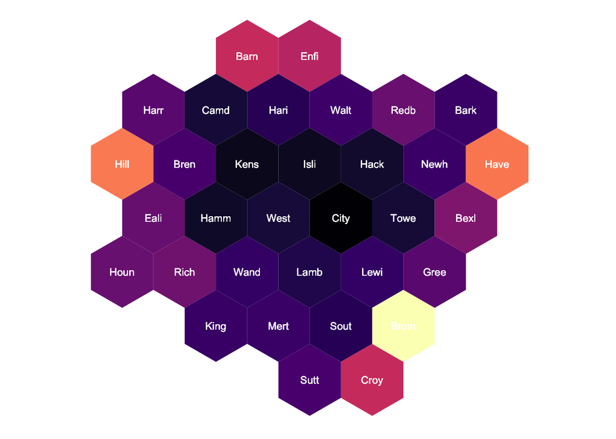

```r
(hexplot <- ggplot(result_df_hex) +
  geom_polygon(aes(x = long, y = lat, fill = HECTARES, group = group)) +
  geom_text(aes(V1, V2, label = substr(NAME, 1, 4)), size = 3, color = "white") +
  scale_fill_viridis(option = 'magma') +
  coord_equal() +
  guides(fill = FALSE) +
  theme_void())
```